# 4 `{ggplot2}` and `{gt}` assembly

When creating a series of outputs, it is desirable to keep them visually unified. Is it possible to combine plots and tables in a single figure? Yes, it is - including tables produced with the `{gt}` package. We will only need a small trick to convert a `gt` table to a *grob*, which we can then combine with a plot created with the famous `{ggplot2}` package.

**1. Make a plot**

Here, we will create a simple violin plot to visualize the distribution of measured δ<sup>13</sup>C across countries in this data set.

```r
p_violin <- ggplot(dat_vegetation, aes(x = country_label, y = delta)) +
  geom_violin(colour = "black", fill = "#005C55FF") +
  labs(x = "",
       y = expression(delta ^13 ~ C)) +
  theme_classic() +
  theme(
    plot.margin = margin(0, 0, 0, 0),
    plot.background = element_blank(),
    panel.background = element_blank(),
    axis.line = element_line(colour = "black", linewidth = 0.75),
    axis.ticks.y = element_line(colour = "black", linewidth = 0.75),
    axis.ticks.x = element_blank(),
    axis.text = element_text(colour = "black", size = 17),
    axis.title = element_text(colour = "black", size = 19),
    aspect.ratio = 0.75
  )
```

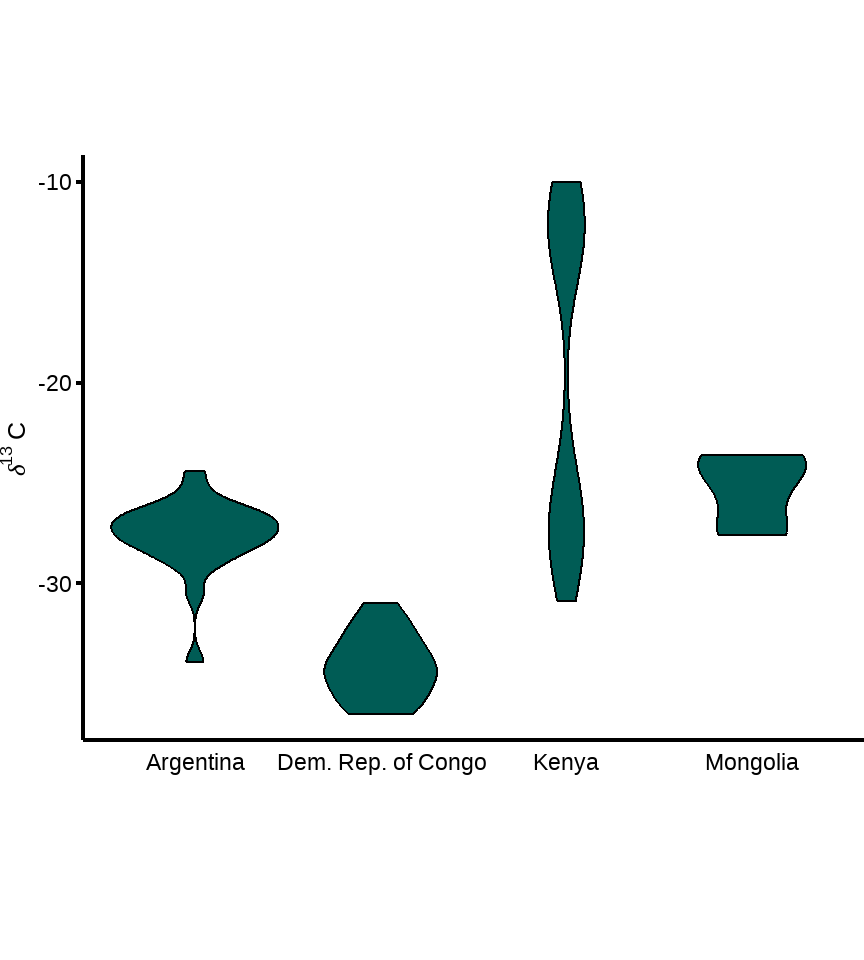

Figure 4.1

**2. Make a `gt` table**

```r
gt_for_plot <- dat_vegetation |>
  group_by(country) |>
  summarize(
    mean_d = mean(delta),
    median_d = median(delta)
  ) |>
  gt() |>
  tab_spanner(columns = contains("_d"), label = md("&delta;^13^C")) |>
  cols_label(
    country = "Country",
    mean_d = "Mean",
    median_d = "Median"
  ) |>
  # decimal places control
  fmt_number(columns = contains("_d"), decimals = 2) |>
  # column labels and spanners in bold font face
  tab_style(
    style = cell_text(weight = "bold"),
    locations = cells_column_labels(everything())
  ) |>
  tab_style(
    style = cell_text(weight = "bold"),
    locations = cells_column_spanners(spanners = everything())
  ) |>
  tab_options(table.font.size = 11)
```

| Country | δ<sup>13</sup>C Mean | δ<sup>13</sup>C Median |
| --- | --- | --- |
| Argentina | −27.62 | −27.45 |
| Democratic Republic of the Congo | −34.11 | −34.35 |
| Kenya | −19.80 | −23.30 |
| Mongolia | −25.28 | −24.75 |

**3. Convert `gt` table to a *grob* (required by `{patchwork}`), which requires new dependencies:**

```r
library(magick)
library(ggplotify)
```

With a small function, we can first save the `gt` table as an `PNG` image and with help of the `{ggplotify}`, further conversion into a *grob* is possible:

```r
as_grob_gt <- function(x) {
  tmp <- tempfile(fileext = ".png")
  gtsave(x, filename = tmp)
  img <- magick::image_read(tmp)

  # Returns a ggplot grob for patchwork
  return(ggplotify::as.grob(img))
}
```

**4. Assemble plot and table into a single figure**

As mentioned above, we will use the `{patchwork}` package for a final plot-table assembly.

```r
library(patchwork)
```

Once `gt` table is converted to a *grob*

```r
gt_grob_patchwork <- as_grob_gt(gt_for_plot)
```

we can treat it as *e.g.*, another `ggplot2` figure and with help of `{patchwork}`’s syntax, control relative positions of plot and table as well as their alignment

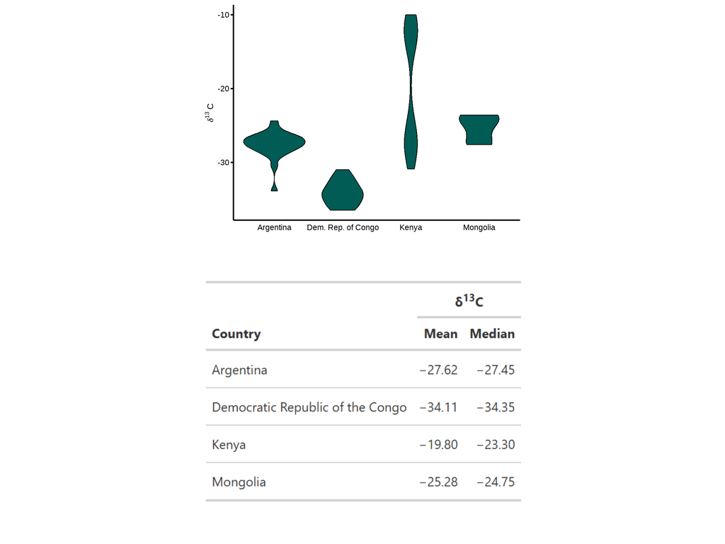

Figure 4.2

```r
p_violin / gt_grob_patchwork
```